# QIF — Quantum Indeterministic Framework for Neural Security

# 5 The Classical Foundation

## 5.1 Coherence Metric

$$C_s = e^{-(\sigma^2_\varphi + \sigma^2_\tau + \sigma^2_\gamma)}$$

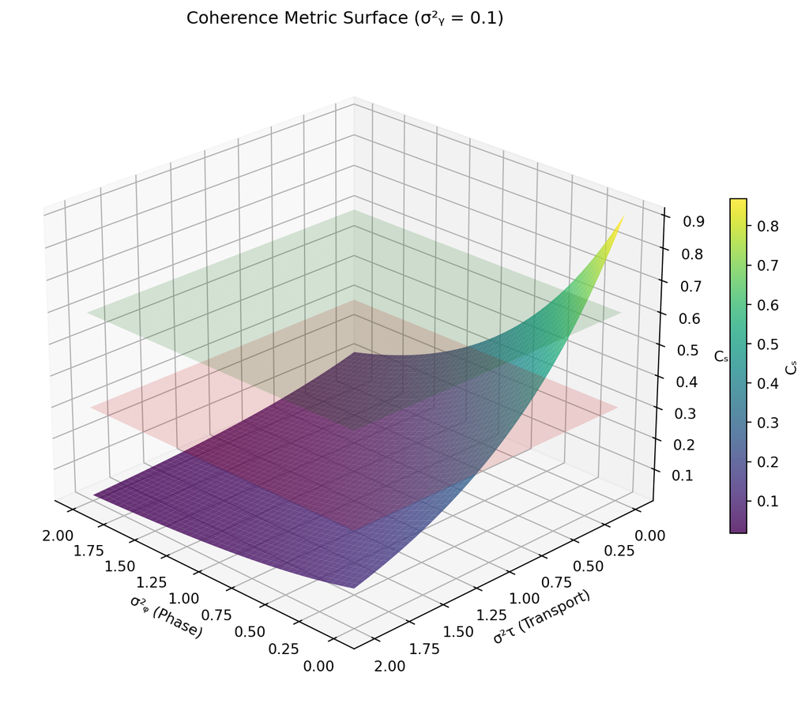

Figure 3: Coherence metric surface: Cₛ drops exponentially as variance increases. Green plane = high threshold (0.6), red plane = low threshold (0.3).

## 5.2 Decision Matrix

Table 6: QIF Decision Thresholds

|  | coherence | auth | action |
| --- | --- | --- | --- |
| 0 | High (Cₛ > 0.6) | Valid | ACCEPT |
| 1 | High (Cₛ > 0.6) | Invalid | REJECT + ALERT |
| 2 | Medium (0.3 < Cₛ < 0.6) | Valid | ACCEPT + FLAG |
| 3 | Medium (0.3 < Cₛ < 0.6) | Invalid | REJECT + ALERT |
| 4 | Low (Cₛ < 0.3) | Any | REJECT + CRITICAL |

## 5.3 Scale-Frequency Relationship

$$v = f \times \lambda$$

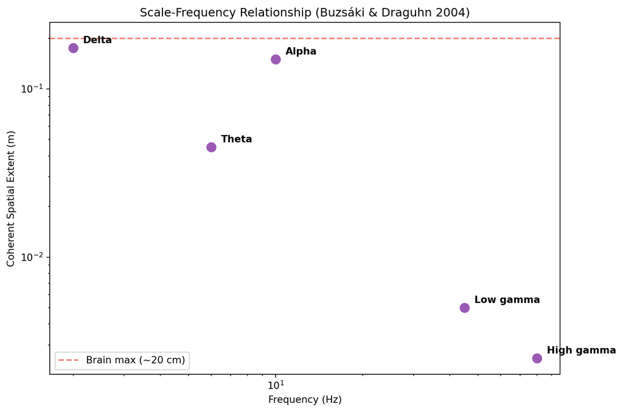

Figure 4: Scale-Frequency: higher frequency = more local coherence. The brain cannot support gamma coherence across its full extent.

# 6 The QI Equation: Two Complementary Views

## 6.1 Candidate 1: Engineering Form

$$QI(t) = \alpha \cdot C_{class} + \beta \cdot (1 - \Gamma_D(t)) \cdot [Q_i + \delta \cdot Q_{entangle}] - \gamma \cdot Q_{tunnel}$$

where $\Gamma_D(t) = 1 - e^{-t/\tau_D}$

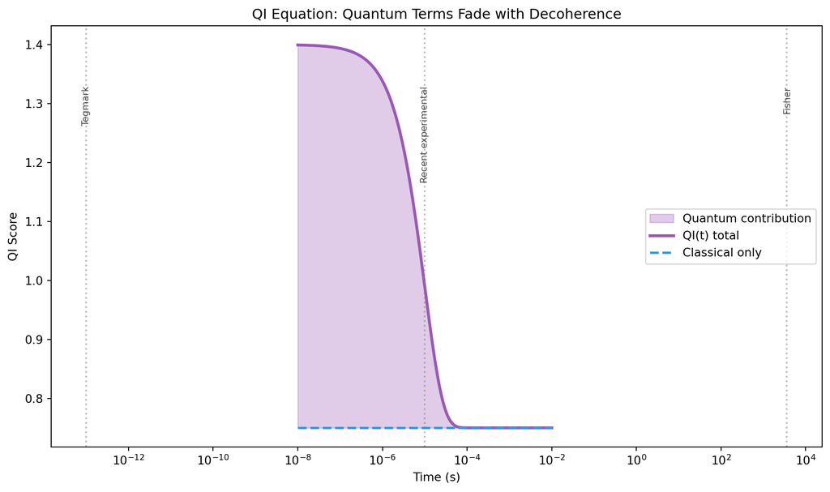

Figure 5: QI score over time: quantum terms (purple shaded) fade as decoherence progresses. Vertical lines mark the three decoherence camps.

Table 7: QI Score Across Decoherence Timescales (t = 1μs, Cclass = 0.8)

|  | Camp | τ_D | Quantum Gate | QI Score |
| --- | --- | --- | --- | --- |
| 0 | Tegmark (skeptic) | 10⁻¹³ s | 0.0000 | 0.7500 |
| 1 | Recent experimental | 10⁻⁵ s | 0.9048 | 1.3381 |
| 2 | Fisher (optimist) | Hours | 1.0000 | 1.4000 |

## 6.2 Candidate 2: Theoretical Form

$$QI = C_{class} \otimes e^{-S_{quantum}}$$

where $S_{quantum} = S_{vN}(\rho(t)) + \lambda \cdot \Phi_{tunnel} - \mu \cdot E(\rho_{AB})$

# 7 Novel Contributions

## 7.1 Quantum Tunneling as Biometric

The tunneling coefficient $T \approx e^{-2\kappa d}$ depends on barrier geometry determined by genetics. Each person’s tunneling profile could be unique — a quantum biometric that is:

1. **Hypothetically unforgeable:** would depend on quantum tunneling
2. **Unique:** depends on individual biology
3. **Unclonable:** no-cloning theorem applies

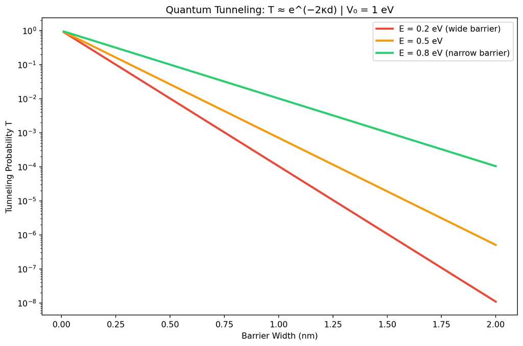

Figure 6: Tunneling probability drops exponentially with barrier width. Different particle energies produce distinct profiles — analogous to different individuals’ ion channels.

## 7.2 Zeno-BCI Stabilization

[figure not shown]

## 7.3 Von Neumann Entropy Non-Monotonicity

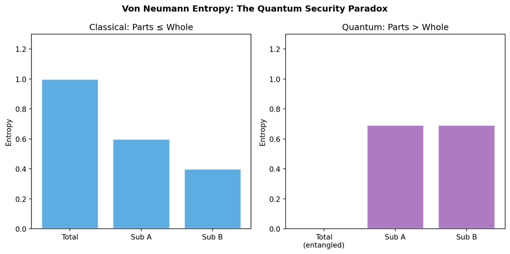

Figure 8: Classical: subsystem entropy ≤ total. Quantum (entangled): subsystem entropy > total. This violation is a security feature — the eavesdropper sees maximum uncertainty while the legitimate system has zero.

# 8 The Decoherence Spectrum

$$\Gamma_D(t) = 1 - e^{-t/\tau_D}$$

QIF treats τ_D as a tunable parameter. The framework works at ANY timescale.

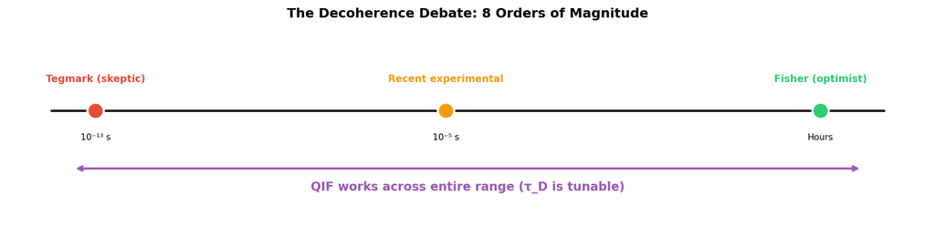

# 9 Security Analysis

## 9.1 Threat Model

Table 8: QIF Threat Model: Classical vs Quantum Detection

|  | Attack Type | Band(s) | Classical Detection? | Quantum Detection? |
| --- | --- | --- | --- | --- |
| 0 | Signal injection | I0–N1 | Yes | Enhanced (coherence metric) |
| 1 | Neural ransomware | N3 | Partial | Yes (QI score drop) |
| 2 | Eavesdropping | I0–N1 | No | Yes (Heisenberg disturbance) |
| 3 | Man-in-the-middle | I0 | Partial | Yes (no-cloning + Bell test) |
| 4 | Quantum tunneling exploit | I0–N1 | No | Yes (tunneling profile anomaly) |
| 5 | Davydov soliton attack | I0–N1 | No | Yes (tunneling term Qtunnel) |
| 6 | Harvest-now-decrypt-later | S3 | No | Prevented (QKD) |
| 7 | Identity spoofing | N3 | Partial | Yes (quantum biometric) |
| 8 | BLE/RF side-channel | S1–S2 | Yes | Enhanced (signal correlation) |
| 9 | Supply chain compromise | S2–S3 | Yes | Enhanced (firmware attestation) |
| 10 | Cloud infrastructure attack | S3 | Yes | Enhanced (QKD for data-in-transit) |
| 11 | Neural data privacy breach | N1–S3 | Yes | Enhanced (cross-band encryption) |

## 9.2 Scenario Testing (Live Computation)

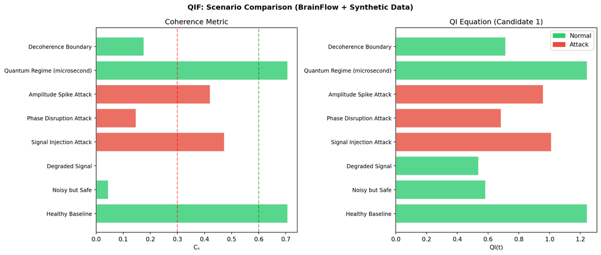

# 10 Experimental Predictions

Table 9: Five Testable Hypotheses from QIF

|  | # | Prediction | How to Test | Expected Outcome |
| --- | --- | --- | --- | --- |
| 0 | 1 | Ion channel tunneling profiles are unique per ... | Single-channel patch clamp + quantum state tom... | Significant inter-subject T(E) variation |
| 1 | 2 | 1kHz+ BCI sampling stabilizes quantum coherenc... | Vary sampling rate, measure coherence time | Coherence ↑ with sampling rate |
| 2 | 3 | Davydov solitons can be generated by THz radia... | THz stimulation of SNARE complexes in vitro | Anomalous vesicle release |
| 3 | 4 | Decoherence at BCI interface is measurable | Quantum state tomography at electrode-tissue j... | τ_D measurement |
| 4 | 5 | QI score drops under quantum-level attack | Simulated attack with quantum instrumentation | Measurable QI(t) decrease |

# 11 Conclusion

QIF delivers:

> *“Life’s most important connections deserve the most thought.”*

# 12 References

See full reference list in QIF-WHITEPAPER.md (50 references in APA format).

*This whitepaper is generated as-code from `qif-lab/`. All figures, tables, and computed values are produced by Python code that reads from a single configuration source (`config.py`) and equation implementation (`qif_equations.py`). Change the equations → re-render → the paper updates.*